# Evidence for tradeoffs between photosynthetic and phagotrophic investments in the mixotrophic chrysophyte Ochromonas

Barbaglia et al

25 December 2022

# Code setup

## Loading packages

Loads packages relevant to the script

```r
# LOAD PACKAGES
require(Rmisc) # Has summarySE function
```

```r
require(sciplot) # Has bargraph.CI function
require(dismo) # For plotting convex hulls
require(rworldmap) # For plotting map of locations
require(ape) # package for phylogenetic trees and Mantel test
```

## Importing data

Imports data and performs some cleanup

```r
# LOAD DATA
# NOTE: You will need to change the file path to wherever this spreadsheet is located. See instructions for a PC here: https://www.wikihow.com/Find-a-File%27s-Path-on-Windows

## PHYSIOLOGY
PAdata <- read.csv("/Users/hollyvm/GoogleSync/StudentWork/GinaBarbaglia/OchTradeoffData.csv")
#### PAdata <- read.csv("/Users/hollyvm/GoogleSync/StudentWork/GinaBarbaglia/PAdata_old.csv")


# Subset the data to exclude strain 2616 & light levels > 200
PAdata <- PAdata[PAdata$Strain!=2616 & PAdata$Light < 200 ,]


## GENETIC DISTANCE
gendist <- read.csv("/Users/hollyvm/GoogleSync/StudentWork/GinaBarbaglia/NumberOfDifferentBases.csv")


## STRAIN GEOGRAPHIC ORIGINS
metadata <- read.csv("/Users/hollyvm/GoogleSync/StudentWork/RyanMarczak/Ochromonas_TradeoffFunctions - CultureOrigins.csv")
metadata <- metadata[metadata$Strain!=2616,]

## BACTERIAL ABUNDANCE
bact.counts <- read.csv("/Users/hollyvm/GoogleSync/StudentWork/GinaBarbaglia/Ochromonas_TradeoffFunctions - PhotoAccBacterialCounts.csv")


## CN data
CNdata <- read.csv("/Users/hollyvm/GoogleSync/StudentWork/GinaBarbaglia/Ochromonas_TradeoffFunctions - Gina_CN.csv",header=T)
```

```r
#### Delete this whole chunk?

# PHOTOSYNTHESIS CALCULATIONS

Cfix.mult <- 0.01728178 # The multiplier 0.01728178 converts from electrons per chlorophyll molecule per second into pg C per pg chlorophyll-a per hour

PAdata$P_I.perC <- PAdata$chl.to.C*PAdata$P_I*Cfix.mult*12 # multiply by 12 because 12hrs light in each day
PAdata$P_I.percell <- PAdata$chl.percell*PAdata$P_I*Cfix.mult*12 # multiply by 12 because 12hrs light in each day

# Manually set photosynthetic rates to 0 if no light.
for(i in 1:dim(PAdata)[1]){
  if(PAdata$Light[i]==0){
    PAdata$P_I[i] <- 0
    PAdata$P_I.perC[i] <- 0
    PAdata$P_I.percell[i] <- 0
    #### PAdata$P_I.cell[i] <- 0
  }
}
```

```r
# GRAZING CALCULATIONS
```

# Setting plotting instructions and properties

```r
# Rainbow of colours for the eight strains
# Colours from: https://github.com/BlakeRMills/MetBrewer - Hokusai 1 + a bit of Hokusai 2
col.a <- rgb(96/255,26/255,16/255)
col.b <- rgb(183/255,51/255,48/255)
col.c <- rgb(234/255,95/255,75/255)
col.d <- rgb(233/255,120/255,47/255)
col.e <- rgb(243/255,186/255,81/255)
col.f <- rgb(120/255,171/255,125/255)
col.g <- rgb(0/255,93/255,148/255)
col.h <- rgb(0/255,56/255,98/255)

# Rainbow of colours with reduced opacity for backgrounds of plots
alpha.bg <- .5
col.a.bg <- rgb(96/255,26/255,16/255,alpha.bg)
col.b.bg <- rgb(183/255,51/255,48/255,alpha.bg)
col.c.bg <- rgb(234/255,95/255,75/255,alpha.bg)
col.d.bg <- rgb(233/255,120/255,47/255,alpha.bg)
col.e.bg <- rgb(243/255,186/255,81/255,alpha.bg)
col.f.bg <- rgb(120/255,171/255,125/255,alpha.bg)
col.g.bg <- rgb(0/255,93/255,148/255,alpha.bg)
col.h.bg <- rgb(0/255,56/255,98/255,alpha.bg)

# Assembling into a vector of colors
col.strains <- c(col.a,col.b,col.c,col.d,col.e,col.f,col.g,col.h)
col.strains.bg <- c(col.a.bg,col.b.bg,col.c.bg,col.d.bg,col.e.bg,col.f.bg,col.g.bg,col.h.bg)

# "Mega" vector alternates saturated and unsaturated, for making barplots that show high and low bacterial treatments side by side
mega.col.strains <- rep(NaN,length(col.strains)*2)
for(i in 1:length(col.strains)){
  mega.col.strains[2*(i-1)+1] <- col.strains[i]
  mega.col.strains[2*i] <- col.strains.bg[i]
}

# Settings for symbol type and expansion factor of low (.X) and high (.R) bacterial treatments
pch.X <- 24
pch.R <- 21
ptcex.X <- .8
ptcex.R <- 1
```

# Growth rates

Ochromonas growth rates increase with light and prey.

We have ordered this plot from left to right in terms of the strains that showed the biggest change in growth with the addition of bacteria. This chunk of code computes that.

```r
# Figuring out strain ordering

# Make a dataframe summarizing the growth rate data
growth.summ <- summarySE(data=PAdata,'Growth.Rate',groupvars=c('Strain','Light','Bact.short'),na.rm=T)

# Compute the difference in growth rates between high and low bacterial treatments
growth.summ.x <- growth.summ[growth.summ$Bact.short=='X',]
growth.summ.r <- growth.summ[growth.summ$Bact.short=='R',]
growth.summ.x$growth.r <- growth.summ.r$Growth.Rate
growth.summ.x$delta.growth <- growth.summ.x$growth.r-growth.summ.x$Growth.Rate

# Make an additional summary across all light levels for each strain
uber.summ <- summarySE(data=growth.summ.x,'delta.growth',groupvars='Strain',na.rm=T)

# Sort the strains by the magnitude of this difference
uber.summ <- uber.summ[order(uber.summ$delta.growth,decreasing=T),]
strains <- uber.summ$Strain # the order command above enforces the order.

# Create a "Strain2" data column in PAdata that contains the strains as ordered; We'll use this later to make barplots in the same order.
PAdata$Strain2 <- factor(PAdata$Strain,levels=strains)
```

This code creates a “rainbow plot function”, which we’ll use throughout the script

```r
rainbowplot <- function(dataset,yvar,ylabel,xlabel,spacer,strains,linelevel,legendlocn,logchoice,ylimits,xlab.cex,toplabomit,xtickomit){

  # 1. Make the main plot
  if(missing(ylimits)){ # if no y-limits are imposed
  if(logchoice == 'y'){
    plot(dataset$Light,dataset[,colnames(dataset)==yvar],las=1,xlab='',ylab=ylabel, type = 'n',xlim=c(0,(150+spacer)*length(strains)-spacer),xaxt='n',log='y', ylim=c(min(dataset[,colnames(dataset)==yvar],na.rm=T),max(dataset[,colnames(dataset)==yvar],na.rm=T)))
  } else {
    plot(dataset$Light,dataset[,colnames(dataset)==yvar],las=1,xlab='',ylab=ylabel, type = 'n',xlim=c(0,(150+spacer)*length(strains)-spacer),xaxt='n') }
  } else { # if y-limits are imposed
  if(logchoice == 'y'){
    plot(dataset$Light,dataset[,colnames(dataset)==yvar],las=1,xlab='',ylab=ylabel, type = 'n',xlim=c(0,(150+spacer)*length(strains)-spacer),xaxt='n',log='y', ylim=ylimits)
  } else {
    plot(dataset$Light,dataset[,colnames(dataset)==yvar],las=1,xlab='',ylab=ylabel, type = 'n',xlim=c(0,(150+spacer)*length(strains)-spacer),xaxt='n',ylim=ylimits) }

  }

  # 2. Add an x-axis on the top (side 3) that indicates strain
  if(missing(toplabomit)){
  axis(side = 3, at = c(0:7)*(150+spacer)+75, labels=strains, lwd.ticks=0,line=-1,tck=0,lwd=0)
  }

  # 3. Label the x-axis
  if(missing(xlab.cex)){
  mtext(xlabel,side=1,line=1.5) # add x-axis label
  } else{
    mtext(xlabel,side=1,line=1.5,cex=xlab.cex)
  }

  # 4. Use a for loop to add a tick along the bottom for each strain
  for(i in 1:length(strains)){
    axis(side = 1, at = (i-1)*(150+spacer)+sort(unique(dataset$Light)),tck=.02,labels=F) # Add x-axis tick marks along the top that indicate light level
    if(missing(xtickomit)){
    axis(side=1, at = (i-1)*(150+spacer), tick=0, labels='0',line=-.75,cex.axis=1)
    axis(side=1, at = (i-1)*(150+spacer)+150, tick=0, labels='150',line=-.75,cex.axis=1)
  }}

  # 5. Add a horizontal dashed line to mark 0 growth
  abline(h=linelevel, lty=2)

  # 6. Create a data summary
  dat.summ <- summarySE(data = dataset, measurevar = yvar, groupvars = c('Strain','Bact.short','Light'),na.rm=T)
  colnames(dat.summ)[5] <- 'YVar'

  # 7. Plot the data for each strain
for(i in 1:length(strains)){
  # 7.1. Subset the data
  subdat <- dataset[dataset$Strain==strains[i],]
  sub.dat.summ <- dat.summ[dat.summ$Strain==strains[i],]

  xcoord.adjust <- (i-1)*(150+spacer) # adjust x-coordinate to space out results

  # 7.2. Plot error bars for each light level
  arrows(sub.dat.summ$Light + xcoord.adjust, sub.dat.summ$YVar+sub.dat.summ$sd, sub.dat.summ$Light + xcoord.adjust, sub.dat.summ$YVar-sub.dat.summ$sd, length = 0.05, angle = 90, code= 3)

  # 7.3. Add lines connecting the points
  lines(sub.dat.summ[sub.dat.summ$Bact.short=='R',]$Light + xcoord.adjust,sub.dat.summ[sub.dat.summ$Bact.short=='R',]$YVar, lwd=2 , col = col.strains[i])
  lines(sub.dat.summ[sub.dat.summ$Bact.short=='X',]$Light + xcoord.adjust,sub.dat.summ[sub.dat.summ$Bact.short=='X',]$YVar, lwd=2 , col = col.strains[i])

  # 7.4. Add big points representing the mean values
  points(sub.dat.summ[sub.dat.summ$Bact.short=='R',]$Light + xcoord.adjust,sub.dat.summ[sub.dat.summ$Bact.short=='R',]$YVar,pch=pch.R,cex=1.5*ptcex.R,bg=col.strains[i],col=col.strains[i])
  points(sub.dat.summ[sub.dat.summ$Bact.short=='X',]$Light + xcoord.adjust,sub.dat.summ[sub.dat.summ$Bact.short=='X',]$YVar,pch=pch.X,cex=1.5*ptcex.X,bg='white',col=col.strains[i])
}

  # 8. Add a legend
  legend(x = legendlocn, inset = 0.00, legend=c('High Bacteria', 'Low Bacteria'), pch=c(pch.R,pch.X), pt.bg=c('black','white'), horiz=T, pt.cex=1.5*c(ptcex.R,ptcex.X),cex=1,bty='n')

}
```

Call the function to make the plot of growth rates

[figure not shown]

```r
# Set the physical amount of space between each strain's plot
spacer <- 80

# Use the 'rainbowplot' function defined above to make the plot. Syntax:
#   First argument = dataset
#   Second argument = y-axis variable
#   Third argument = y-axis label
#   Fourth argument = x-axis label
#   Fifth argument = amount of space between plots
#   Sixth argument = order of the strains
#   Seventh argument = horizontal line position, or NA if none needed
#   Eigth argument = location for the legend
#   Ninth argument = log scaling of y axis, enter 'y' or 'n'
#   Tenth argument = y axis limits (optional)
#   Eleventh argument = expansion factor for x-axis label (optional)
#   Twelfth argument = 'n' if omitting top labels (optional)
#   xtickomit == omits x tick labels (optional)
rainbowplot(PAdata,'Growth.Rate','Growth Rate (per day)','Light Level (grouped by strain)',spacer,strains,0,'topright','n')
```

Growth increases and saturates with increasing photosynthetic rates, and is generally higher with higher bacterial availability.

# Computing carbon use efficiency

Carbon use efficiency (CUE) = amount of carbon used for growth / (total amount of carbon acquired)

We have the growth rate, which is in units of per day. Or, more explicitly, in units of carbon turned into new biomass per carbon of current biomass per day. That’s the numerator of CUE.

For the carbon acquired, we need to sum up the carbon gained through photosynthesis, and the carbon gained through grazing.

For photosynthesis, this is photosynthetic rate * amount of photosynthetic machinery * 12 hrs of sunlight per day. But we have to be careful to do all of this in units of per gram of carbon.

```r
# Growth.Rate <- rate of growth, in units of per day
# C.perOch <- ng C per Ochromonas cell

# chl.percell <- pg chl-a per cell
# chl.to.C <- mg chl-a per g C
# P_I <- electrons transferred per molecule of chlorophyll-a

Cfix.mult <- 0.01728178 # The multiplier 0.01728178 converts from electrons per chlorophyll molecule per second into pg C per pg chlorophyll-a per hour

PAdata$chl.to.C <- PAdata$chl.percell/PAdata$C.perOch*1000 # mg chl-a per g carbon

# pg C fixed via photosynthesis per pg of Ochromonas per day = electrons per molecule of chl-a per second * [pg C per pg chl-a per hr / electrons per molecule of chl-a per second] * 12hrs of light per day * pg chl per pg C
PAdata$P_I.perC <- PAdata$P_I*Cfix.mult*12*PAdata$chl.to.C/1000 # multiply by 12 because 12hrs light in each day; divide by 1000 because chl to c in mg per g


# Best.g <- number of bacteria estimated to be eaten per Ochromonas cell per day

fgC.per.bact <- 113.5996283 # fentograms C per bacterial cell
# pg C of bacteria per pg C of Ochromonas per day = bacteria per och per day * 113 fgC/bact * 0.001 pg/fg * 1 och/pg C per och
PAdata$C.from.grazing.perCperday <- PAdata$Best.g*fgC.per.bact*0.001/PAdata$C.perOch

PAdata$attack.per.C.scaled <- PAdata$attack.per.C*24*1000*1000 # scaled to per g carbon per day

PAdata$CUE <- PAdata$Growth.Rate/(PAdata$C.from.grazing.perCperday+PAdata$P_I.perC)
```

Make a barplot of the results

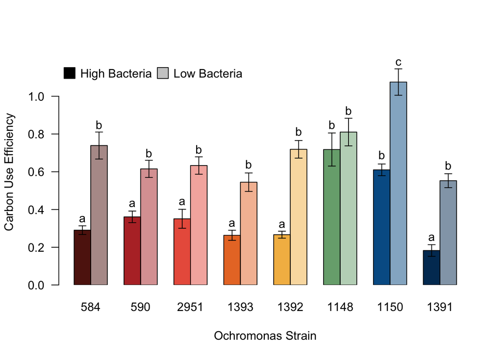

```r
# Make the barplot
bargraph.CI(Strain2,CUE,group=Bact.short, data=PAdata,las=1,legend=F,xlab='Ochromonas Strain',ylab='Carbon Use Efficiency',leg.lab=c('High Bacteria','Low Bacteria'),col=mega.col.strains,err.width = .05,ylim=c(0,1.199))
legend(x='topleft',inset=0.0,legend=c('High Bacteria','Low Bacteria'),bty='n',pt.cex=2.3,pch=22,pt.bg=c('black','gray80'),horiz=T)

# Uncomment to see results of the Tukey test
#TukeyHSD(aov(CUE~Bact.short*Strain2,data=PAdata))

# Add text labels to indicate significance
text(x = c(1.5,2.5,4.5,5.5,7.5,8.5,10.5,11.5,13.5,14.5,16.5,17.5,19.5,20.5,22.5,23.5),y=c(0.35,0.85,0.43,.7,.44,.72,.325,.64,.32,.815,.85,.925,.69,1.18,.25,.635),c('a','b','a','b','a','b','a','b','a','b','b','b','b','c','a','b'))
```

We were curious about whether carbon use efficiency tended to decline as growth rates increased. Here’s a plot of CUE by strain as a function of growth rate. Generally, no support for this hypothesis.

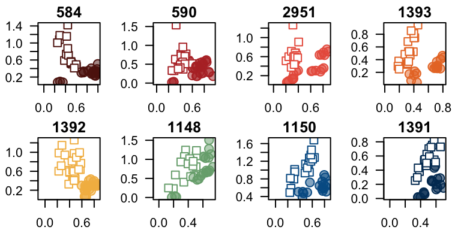

```r
par(mar=c(2,2.5,1.5,1),mfrow=c(2,4))
for(i in 1:length(strains)){
  subdat <- PAdata[PAdata$Strain==strains[i]&PAdata$Light<200,]
  plot(subdat$Growth.Rate,subdat$CUE,xlab='Growth Rate',ylab='Carbon Use Efficiency',main=strains[i],las=1,pch=c(21,22)[as.factor(subdat$Bact.short)],cex=1.5,col=col.strains[i],bg=c(col.strains.bg[i],'white')[as.factor(subdat$Bact.short)])
}
```

# Explaining growth rates with photosynthesis and heterotrophy

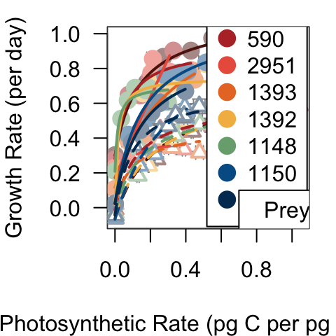

```r
par(mar=c(4,4,1,1),mfrow=c(1,1))

# PHOTOSYNTHESIS PREDICTS GROWTH: PHOTOSYNTHESIS PER CARBON

plot(PAdata$Growth.Rate~PAdata$P_I.perC,col=col.strains[as.factor(PAdata$Strain)],las=1,xlab='Photosynthetic Rate (pg C per pg C per d)', ylab='Growth Rate (per day)',lwd=.5,pch=21,type='n')

mu.summ <- summarySE(data = PAdata, measurevar = 'Growth.Rate', groupvars = c('Strain','Bact.short','Light'),na.rm=T)
PI.summ <- summarySE(data = PAdata, measurevar = 'P_I.perC', groupvars = c('Strain','Bact.short','Light'),na.rm=T)

for(i in 1:length(strains)){
  sub.mu <- mu.summ[mu.summ$Strain==strains[i],]
  sub.pi <- PI.summ[PI.summ$Strain==strains[i],]
  arrows(sub.pi$P_I.perC,sub.mu$Growth.Rate+sub.mu$se,sub.pi$P_I.perC,sub.mu$Growth.Rate-sub.mu$se,code=3,angle=90,length=0.05)
  arrows(sub.pi$P_I.perC+sub.pi$se,sub.mu$Growth.Rate,sub.pi$P_I.perC-sub.pi$se,sub.mu$Growth.Rate,code=3,angle=90,length=0.05)
  points(sub.mu$Growth.Rate~sub.pi$P_I.perC,pch=c(pch.R,pch.X)[as.factor(sub.mu$Bact.short)],col=col.strains[i],lwd=2,cex=1.5*c(ptcex.R,ptcex.X)[as.factor(sub.mu$Bact.short)],bg=c(col.strains[i],'white')[as.factor(sub.mu$Bact.short)])
}

rect(-10,-10,100,10,col=rgb(1,1,1,.5)) # Adds a white rectangle that's 50% transparent to make the points "fade out" a little bit

for(i in 1:length(strains)){
  sub.mu <- mu.summ[mu.summ$Strain==strains[i],]
  sub.pi <- PI.summ[PI.summ$Strain==strains[i],]

  data.x <- as.data.frame(cbind(sub.mu[sub.mu$Bact.short=='X',]$Growth.Rate,sub.pi[sub.pi$Bact.short=='X',]$P_I.perC))
  colnames(data.x) <- c('Growth','PI')
  c.est <- data.x[1,1]
  a.est <- 5
  data.x[1,2] <- 0
  fit.x <- nls(Growth~a*PI/(h + PI)+c, data = data.x, start = list(a = a.est, h =1, c = c.est))
  pi.min <- min(data.x$PI,na.rm=T); pi.max <- max(data.x$PI,na.rm=T); pi.set <- seq(from=pi.min,to = pi.max,length.out=50)
  mu.set <- summary(fit.x)$parameters[1,1]*pi.set / (summary(fit.x)$parameters[2,1]+pi.set)+summary(fit.x)$parameters[3,1]
  lines(pi.set,mu.set,lwd=2,col=col.strains[i],lty=2)

  data.r <- as.data.frame(cbind(sub.mu[sub.mu$Bact.short=='R',]$Growth.Rate,sub.pi[sub.pi$Bact.short=='R',]$P_I.perC))
  colnames(data.r) <- c('Growth','PI')
  c.est <- data.r[1,1]
  a.est <- (data.r[2,1]-data.r[1,1])/data.r[2,2]
  fit.r <- nls(Growth~a*PI/(h + PI)+c, data = data.r, start = list(a = a.est, h =1, c = c.est))
  pi.min <- min(data.r$PI,na.rm=T); pi.max <- max(data.r$PI,na.rm=T); pi.set <- seq(from=pi.min,to = pi.max,length.out=50)
  mu.set <- summary(fit.r)$parameters[1,1]*pi.set / (summary(fit.r)$parameters[2,1]+pi.set)+summary(fit.r)$parameters[3,1]
  lines(pi.set,mu.set,lwd=2,col=col.strains[i])
}

legend(x = 'bottomright', inset = 0.01, legend=strains, pch=21,pt.cex=1.5, col=col.strains,pt.bg=col.strains, title='Strain',pt.lwd=2)
legend(x = .7, y = 0.1, legend=c('High','Low'), title='Prey',pch=c(pch.R,pch.X),pt.cex=1.5*c(ptcex.R,ptcex.X),pt.bg=c('black','white'),pt.lwd=2)
```

Supplemental figure for heterotrophy

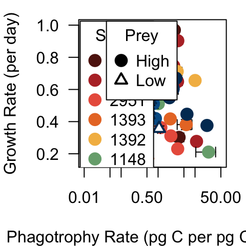

```r
par(mar=c(4,4,1,1),mfrow=c(1,1))

plot(PAdata$Growth.Rate~PAdata$C.from.grazing.perCperday,col=col.strains[as.factor(PAdata$Strain)],las=1,xlab='Phagotrophy Rate (pg C per pg C per d)', ylab='Growth Rate (per day)',lwd=.5,pch=21,type='n',log='x',xlim=c(0.01,50),ylim=c(0.15,1))

mu.summ <- summarySE(data = PAdata, measurevar = 'Growth.Rate', groupvars = c('Strain','Bact.short','Light'),na.rm=T)
het.summ <- summarySE(data = PAdata, measurevar = 'C.from.grazing.perCperday', groupvars = c('Strain','Bact.short','Light'),na.rm=T)

for(i in 1:length(strains)){
  sub.mu <- mu.summ[mu.summ$Strain==strains[i],]
  sub.pi <- het.summ[het.summ$Strain==strains[i],]
  arrows(sub.pi$C.from.grazing.perCperday,sub.mu$Growth.Rate+sub.mu$se,sub.pi$C.from.grazing.perCperday,sub.mu$Growth.Rate-sub.mu$se,code=3,angle=90,length=0.05)
  arrows(sub.pi$C.from.grazing.perCperday+sub.pi$se,sub.mu$Growth.Rate,sub.pi$C.from.grazing.perCperday-sub.pi$se,sub.mu$Growth.Rate,code=3,angle=90,length=0.05)
  points(sub.mu$Growth.Rate~sub.pi$C.from.grazing.perCperday,pch=c(pch.R,pch.X)[as.factor(sub.mu$Bact.short)],col=col.strains[i],lwd=2,cex=1.5*c(ptcex.R,ptcex.X)[as.factor(sub.mu$Bact.short)],bg=c(col.strains[i],'white')[as.factor(sub.mu$Bact.short)])
}

legend(x = 'topleft', inset = 0.01, legend=strains, pch=21,pt.cex=1.5, col=col.strains,pt.bg=col.strains,title='Strain',pt.lwd=2)
#legend(x = 'topleft', inset = 0.01, legend=strains, pch=21,pt.cex=1.5, col=col.strains,pt.bg=col.strains,title='Strain')

legend(x = .04, y = 1.025, legend=c('High','Low'), title='Prey',pch=c(pch.R,pch.X),pt.cex=1.5*c(ptcex.R,ptcex.X),pt.bg=c('black','white'),pt.lwd=2)
```

# Phenotypic plasticity

Mixotroph metabolic investment traits vary with environmental conditions. (1) Chlorophyll investment decreases with light. (2) Attack rates decrease with prey availability

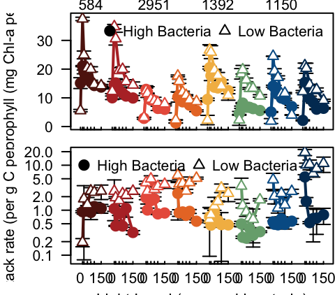

```r
# Set the amount of space between each curve
spacer <- 80

# Set up 2-row figure

matrixreps <- 10
layout(matrix(c(3,rep(1,matrixreps),rep(2,matrixreps),4),nrow=2+2*matrixreps,ncol=1))
par(mar=c(1,4,0,0.1))


# TOP ROW: CHLOROPHYLL
rainbowplot(PAdata,'chl.to.C','Chlorophyll (mg Chl-a per g C)','',spacer,strains,NA,'topright','n',xtickomit='T')
mtext('(a)',side=1,at=-235,line=-16)

# BOTTOM ROW: ATTACK RATE
rainbowplot(PAdata[PAdata$Light>0,],'attack.per.C.scaled','Attack rate (per g C per day)','Light Level (grouped by strain)',spacer,strains,NA,'topleft','y',c(.08,20),toplabomit='T',xlab.cex = .7)
mtext('(b)',side=1,at=-235,line=-16)
```

# Tradeoffs

Some lineages experience sharp tradeoffs between investments: As chlorophyll per carbon increases, attack rates per carbon decrease. These tradeoffs only seem to emerge when growth rates are low, implying that cells are resource-limited and thus might be maximizing their investments in each form of metabolism.

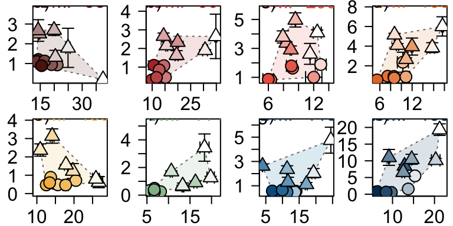

```r
# Compile summary data

PAdata$Strain.Bact.Light <- paste(PAdata$Strain,PAdata$Bact.short,PAdata$Light,sep='.')
growth.summ.C <- summarySE(data=PAdata[PAdata$Light>0,],'Growth.Rate',groupvars=c('Strain.Bact.Light'),na.rm=T)
chl.summ.C <- summarySE(data=PAdata[PAdata$Light>0,],'chl.to.C',groupvars=c('Strain.Bact.Light'),na.rm=T)
att.summ.C <- summarySE(data=PAdata[PAdata$Light>0,],'attack.per.C.scaled',groupvars=c('Strain.Bact.Light'),na.rm=T)


growth.summ.C$mean.chl <- chl.summ.C$chl.to.C[match(growth.summ.C$Strain.Bact.Light,chl.summ.C$Strain.Bact.Light)]
growth.summ.C$se.chl <- chl.summ.C$se[match(growth.summ.C$Strain.Bact.Light,chl.summ.C$Strain.Bact.Light)]

growth.summ.C$mean.att <- att.summ.C$attack.per.C.scaled[match(growth.summ.C$Strain.Bact.Light,att.summ.C$Strain.Bact.Light)]
growth.summ.C$se.att <- att.summ.C$se[match(growth.summ.C$Strain.Bact.Light,att.summ.C$Strain.Bact.Light)]


growth.summ.C$Strain <- PAdata$Strain[match(growth.summ.C$Strain.Bact.Light,PAdata$Strain.Bact.Light)]
growth.summ.C$Bact.short <- PAdata$Bact.short[match(growth.summ.C$Strain.Bact.Light,PAdata$Strain.Bact.Light)]


# Set up plot
par(mar=c(2,2.2,.4,.4),mfrow=c(2,4))
subplotlabels <- c("(a)","(b)",'(c)',"(d)","(e)","(f)","(g)","(h)")

for(i in 1:length(strains)){
  plot(PAdata[PAdata$Light>0&PAdata$Strain==strains[i],]$chl.to.C,PAdata[PAdata$Light>0&PAdata$Strain==strains[i],]$attack.per.C.scaled,xlab='Photo. Invest.', ylab='Hetero. Invest.',type='n',las=1,cex.axis=1.5)

  # Subset the data for the strain
  subdat <- growth.summ.C[growth.summ.C$Strain==strains[i],]

  # Set up color ramp based on growth rate
  subdat$order <- findInterval(subdat$Growth.Rate,sort(subdat$Growth.Rate))
  pal = colorRampPalette(c("white",col.strains[i]))
  #pal = colorRampPalette(c(col.strains[i],"white"))

  # Add convex hull
  ch <- convHull(cbind(subdat$mean.chl,subdat$mean.att))
  plot(ch,add=T,col=pal(10)[2],lty=3,border='gray50')

  # Add error bars
  arrows(subdat$mean.chl+subdat$se.chl,subdat$mean.att,subdat$mean.chl-subdat$se.chl,subdat$mean.att,angle=90,code=3,length=.05)
  arrows(subdat$mean.chl,subdat$mean.att+subdat$se.att,subdat$mean.chl,subdat$mean.att-subdat$se.att,angle=90,code=3,length=.05)

  # Add points
  points(subdat$mean.chl,subdat$mean.att,pch=c(21,24)[as.factor(subdat$Bact.short)],cex=1.3*c(1.6,1.5)[as.factor(subdat$Bact.short)],lwd=1,bg=pal(nrow(subdat))[subdat$order]) #c('goldenrod','dodgerblue')[as.factor(sub.chl$Bact.short)])
  text(mean(c(min(PAdata[PAdata$Light>0&PAdata$Strain==strains[i],]$chl.to.C,na.rm=T),max(PAdata[PAdata$Light>0&PAdata$Strain==strains[i],]$chl.to.C,na.rm=T))),max(PAdata[PAdata$Light>0&PAdata$Strain==strains[i],]$attack.per.C.scaled,na.rm=T)*.92,paste('CCMP ',strains[i],sep=''),col=col.strains[i],pos=3,cex=1.5)
  text(min(PAdata[PAdata$Light>0&PAdata$Strain==strains[i],]$chl.to.C,na.rm=T)*1.08,max(PAdata[PAdata$Light>0&PAdata$Strain==strains[i],]$attack.per.C.scaled,na.rm=T)*.92,subplotlabels[i],pos=3,cex=1.5)
}
```

# Measuring synergies vs tradeoffs

Just because you have a tradeoff in how you can make investments doesn’t mean that you can’t experience synergies in the yields of those investments.

What would this look like?

We know how to look for tradeoffs in investments by looking for cases in which attack rates and chlorophyll have negative relationships. But how can we observe synergies?

1. Photosynthetic efficiency, rate of photosynthesis per chlorophyll, and rate of photosynthesis per carbon in high and low prey levels

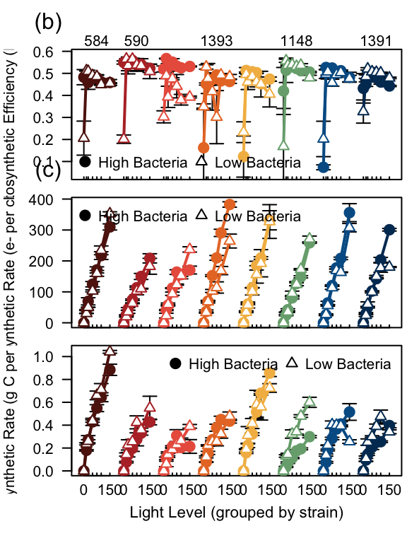

```r
# Set up 3-row figure
par(mar=c(4,4,1,1),mfrow=c(3,1))

layout(matrix(c(4,1,1,1,2,2,2,3,3,3,5),nrow=11,ncol=1))
par(mar=c(1,4,0,.3))

## ROW 1:

# Set the amount of space between each curve
spacer <- 80

# TOP ROW: Photosynthetic efficiency
rainbowplot(PAdata[PAdata$Light>-10,],'Fv.Fm','Photosynthetic Efficiency (Fv/Fm)','',spacer,strains,NA,'bottomleft','n',xlab.cex=.7,xtickomit = T)
mtext('(a)',side=1,at=-205,line=-17.5)

# MIDDLE ROW: PHOTOSYNTHESIS PER CHLOROPHYLL
rainbowplot(PAdata,'P_I','Photosynthetic Rate (e- per chl-a per s)','',spacer,strains,NA,'topleft','n',xlab.cex=.7,xtickomit = T,toplabomit = T)
mtext('(b)',side=1,at=-205,line=-17.5)

# BOTTOM ROW: PHOTOSYNTHESIS PER CARBON
rainbowplot(PAdata,'P_I.perC','Photosynthetic Rate (g C per g C per d)','Light Level (grouped by strain)',spacer,strains,NA,'topright','n',xlab.cex=.7,toplabomit = T)
mtext('(c)',side=1,at=-205,line=-17.5)
```

2. Rates of grazing as a function of photosynthetic rates

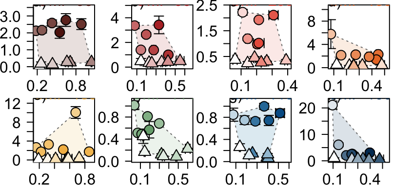

```r
# Add new summary data

phot.summ.C <- summarySE(data=PAdata[PAdata$Light>0,],'P_I.perC',groupvars=c('Strain.Bact.Light'),na.rm=T)
graz.summ.C <- summarySE(data=PAdata[PAdata$Light>0,],'C.from.grazing.perCperday',groupvars=c('Strain.Bact.Light'),na.rm=T)


growth.summ.C$mean.phot <- phot.summ.C$P_I.perC[match(growth.summ.C$Strain.Bact.Light,phot.summ.C$Strain.Bact.Light)]
growth.summ.C$se.phot <- phot.summ.C$se[match(growth.summ.C$Strain.Bact.Light,phot.summ.C$Strain.Bact.Light)]

growth.summ.C$mean.graz <- graz.summ.C$C.from.grazing.perCperday[match(growth.summ.C$Strain.Bact.Light,graz.summ.C$Strain.Bact.Light)]
growth.summ.C$se.graz <- graz.summ.C$se[match(growth.summ.C$Strain.Bact.Light,graz.summ.C$Strain.Bact.Light)]


# Set up plot
#par(mar=c(4,4,1,1),mfrow=c(2,4))
par(mar=c(2,2.7,.4,.3),mfrow=c(2,4))


for(i in 1:length(strains)){
  plot(PAdata[PAdata$Light>0&PAdata$Strain==strains[i],]$P_I.perC,PAdata[PAdata$Light>0&PAdata$Strain==strains[i],]$C.from.grazing.perCperday,xlab='Photo. Rate', ylab='Hetero. Rate',type='n',las=1,cex.axis=1.5)

  # Subset the data for the strain
  subdat <- growth.summ.C[growth.summ.C$Strain==strains[i],]

  # Set up color ramp based on growth rate
  subdat$order <- findInterval(subdat$Growth.Rate,sort(subdat$Growth.Rate))
  pal = colorRampPalette(c("white",col.strains[i]))
  #pal = colorRampPalette(c(col.strains[i],"white"))

  # Add convex hull
  ch <- convHull(cbind(subdat$mean.phot,subdat$mean.graz))
  plot(ch,add=T,col=pal(10)[2],lty=3,border='gray50')

  # Add error bars
  arrows(subdat$mean.phot+subdat$se.phot,subdat$mean.graz,subdat$mean.phot-subdat$se.phot,subdat$mean.graz,angle=90,code=3,length=.05)
  arrows(subdat$mean.phot,subdat$mean.graz+subdat$se.graz,subdat$mean.phot,subdat$mean.graz-subdat$se.graz,angle=90,code=3,length=.05)

  # Add points
  points(subdat$mean.phot,subdat$mean.graz,pch=c(21,24)[as.factor(subdat$Bact.short)],cex=1.3*c(1.6,1.5)[as.factor(subdat$Bact.short)],lwd=1,bg=pal(nrow(subdat))[subdat$order])

  text(mean(c(min(PAdata[PAdata$Light>0&PAdata$Strain==strains[i],]$P_I.perC,na.rm=T),max(PAdata[PAdata$Light>0&PAdata$Strain==strains[i],]$P_I.perC,na.rm=T))),max(PAdata[PAdata$Light>0&PAdata$Strain==strains[i],]$C.from.grazing.perCperday,na.rm=T)*.925,paste('CCMP ',strains[i],sep=''),col=col.strains[i],pos=3, cex=1.5)
  text(min(PAdata[PAdata$Light>0&PAdata$Strain==strains[i],]$P_I.perC,na.rm=T)*1.15,max(PAdata[PAdata$Light>0&PAdata$Strain==strains[i],]$C.from.grazing.perCperday,na.rm=T)*.92,subplotlabels[i],pos=3,cex=1.5)
}
```

## Do a nitrogen budget

First let’s make bargraphs of the C per cell, N per cell, and C:N ratios of the Ochromonas.

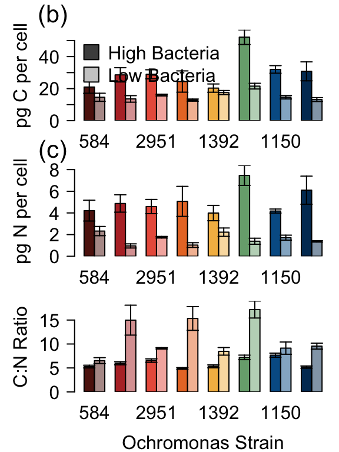

```r
# Some data cleanup
CNdata$Strain2 <- factor(CNdata$Strain,levels=strains) # Orders the strains for plotting according to growth differential
CNdata$Bact.short <- substr(CNdata$Bact,1,1) # Uses the first character of the bacterial treatment as the identifier
CNdata <- CNdata[CNdata$Bact.short%in%c("X","R"),] # Eliminates additional data (e.g., CN analyzer controls and empty rows)

layout(matrix(c(1,1,1,2,2,2,3,3,3,4),nrow=10))
par(mar=c(1,5,2,.5))

bargraph.CI(Strain2,C.perOch,group=Bact.short, data=CNdata,las=1,legend=F,xlab='',ylab='',col=mega.col.strains,err.width = .05, cex.axis=1.5, cex.names=1.5)
legend(x='topleft',inset=0.0,legend=c('High Bacteria','Low Bacteria'),bty='n',pt.cex=3,pch=22,pt.bg=c('gray30','gray80'),cex=1.5)
mtext('pg C per cell',side=2,line=3,cex=1.)
mtext('(a)',side=1,line=-16.5,at=-2,cex=1.3)

bargraph.CI(Strain2,N.perOch,group=Bact.short, data=CNdata,las=1,legend=F,xlab='',ylab='',col=mega.col.strains,err.width = .05, cex.axis=1.5, cex.names=1.5)
#legend(x='topleft',inset=0.0,legend=c('High Bacteria','Low Bacteria'),bty='n',pt.cex=3,pch=22,pt.bg=c('gray30','gray80'),cex=1.5)
mtext('pg N per cell',side=2,line=3,cex=1.)
mtext('(b)',side=1,line=-16.5,at=-2,cex=1.3)

bargraph.CI(Strain2,CN.Och,group=Bact.short, data=CNdata,las=1,legend=F,xlab='Ochromonas Strain',ylab='',col=mega.col.strains,err.width = .05, cex.axis=1.5, cex.names=1.5)
#legend(x='topleft',inset=0.0,legend=c('High Bacteria','Low Bacteria'),bty='n',pt.cex=3,pch=22,pt.bg=c('gray30','gray80'),cex=1.5)
mtext('Ochromonas Strain',side=1,line=3,cex=1)
mtext('C:N Ratio',side=2,line=3,cex=1.)
mtext('(c)',side=1,line=-16.5,at=-2,cex=1.3)
```

Here we are calculating the amount of nitrogen that the cells get from grazing, vs how much they need to get in order to make their own machinery. Negative numbers mean they have to be taking up some inorganic N directly.

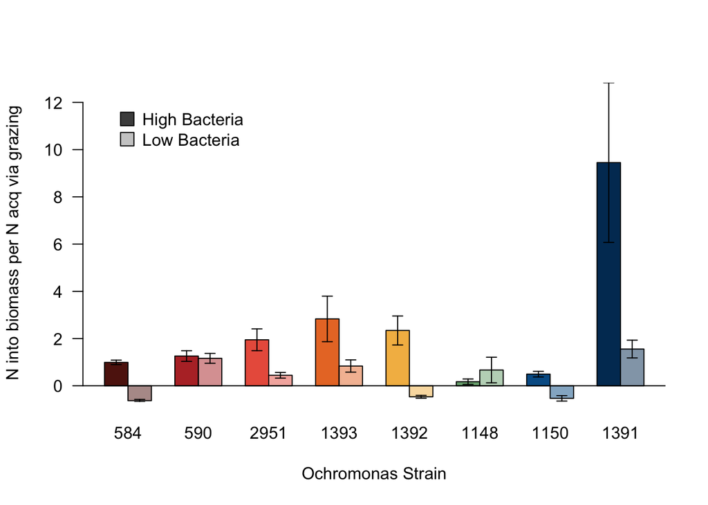

```r
CN.bacteria <- 106/16 # 10.1 # Average number from Michelle's data.
PAdata$N.from.grazing.perCperday <- PAdata$C.from.grazing.perCperday/CN.bacteria # Convert carbon from bacteria into nitrogen from bacteria
PAdata$N.from.grazing.perNperday <- PAdata$N.from.grazing.perCperday*(PAdata$C.perOch/PAdata$N.perOch) #multiply by Ochromonas C:N ratio to get Nitrogen per Ochromonas Nitrogen per day

PAdata$N.deficit <- (PAdata$N.from.grazing.perNperday - PAdata$Growth.Rate)/PAdata$Growth.Rate

bargraph.CI(Strain2,N.deficit,group=Bact.short, data=PAdata[PAdata$Light>0,],las=1,legend=F,xlab='Ochromonas Strain',ylab='N into biomass per N acq via grazing',leg.lab=c('High Bacteria','Low Bacteria'),col=mega.col.strains,err.width = .05)
legend(x='topleft',inset=0.05,legend=c('High Bacteria','Low Bacteria'),bty='n',pt.cex=2,pch=22,pt.bg=c('gray30','gray80'))
abline(h=0)
```

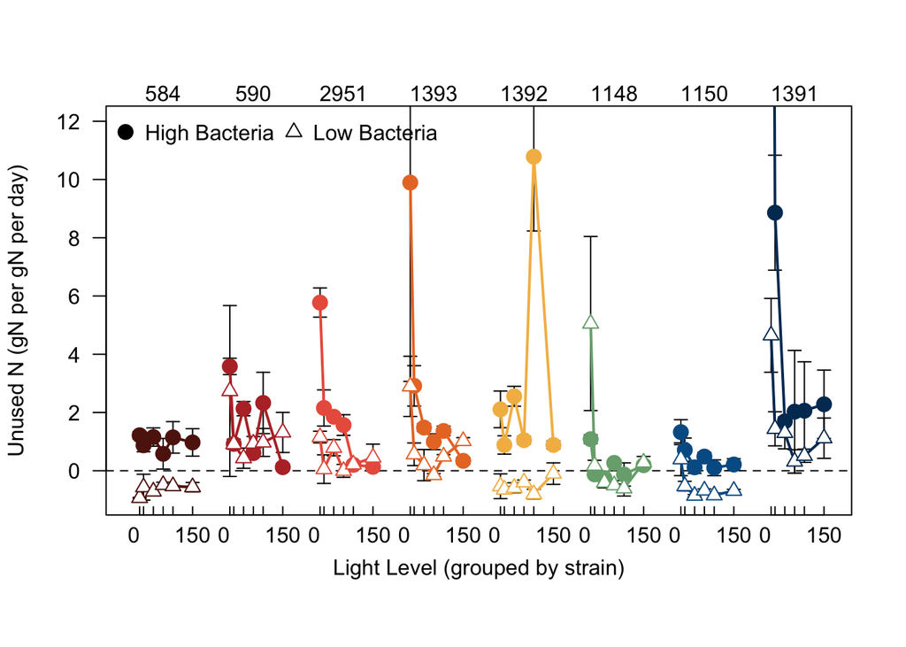

```r
#plot(PAdata$Growth.Rate~PAdata$N.from.grazing.perCperday)
#abline(a = 0,b = 1)

rainbowplot(PAdata[PAdata$Light>0,],'N.deficit','Unused N (gN per gN per day)','Light Level (grouped by strain)',spacer,strains,0,'topleft',logchoice='n',ylimits=c(-1,12))
```

Generally, numbers are positive, indicating that (so long as we assume 100% conversion efficiency) Ochromonas cells can meet their N demand from phagotrophy.

## Nitrogen budget for the total culture

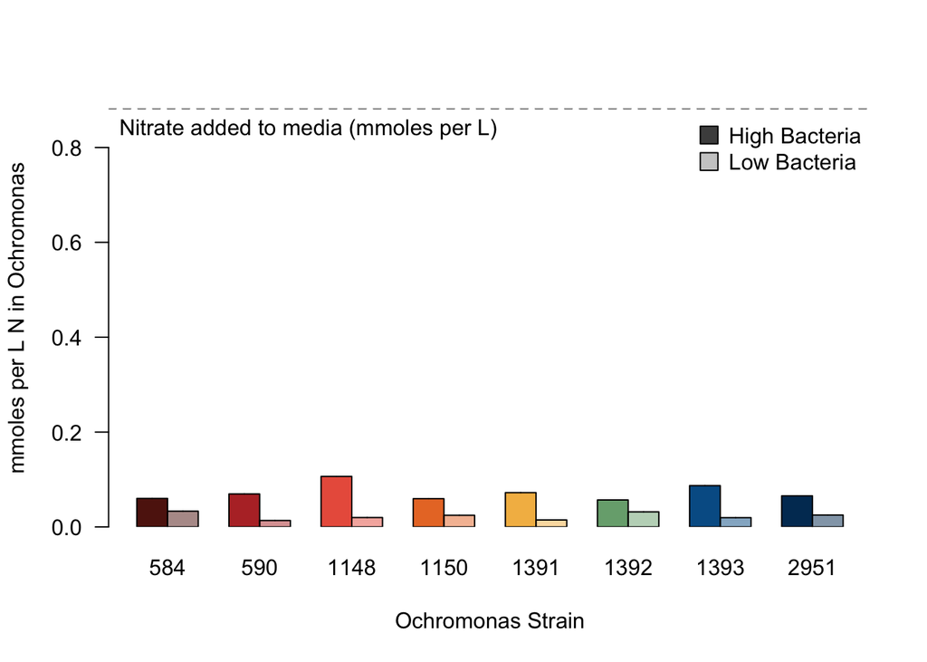

```r
NO3.molar.media <- 0.000882  # concentration of N in Nitrate in K media
# https://ncma.bigelow.org/PDF%20Files/DOC-050.000%20NCMA%20Website%20algal%20medium%20K%202020.pdf


Approx.Och.Conc <- 200000 # approx max population size of Ochromonas per mL while still in exponential growth

PAdata$TotalNinOch.pgNpermL <- PAdata$N.perOch*Approx.Och.Conc
PAdata$TotalNinOch.molperL <- PAdata$TotalNinOch.pgNpermL * 1000 / (10^12) / 14.01 # 1000 mL per L; 10^12 pg per g; 14.01 g per mol N


bargraph.CI(Strain,TotalNinOch.molperL*1000,group=Bact.short, data=PAdata[PAdata$Strain!=2616,],las=1,legend=F,xlab='Ochromonas Strain',ylab='mmoles per L N in Ochromonas',leg.lab=c('High Bacteria','Low Bacteria'),col=mega.col.strains,err.width = .05,ylim=c(0,NO3.molar.media*1000))
legend(x='topright',inset=0.0,legend=c('High Bacteria','Low Bacteria'),bty='n',pt.cex=2,pch=22,pt.bg=c('gray30','gray80'))
abline(h=NO3.molar.media*1000,lty=2)
text(0,NO3.molar.media*950,'Nitrate added to media (mmoles per L)',pos=4)
```

# LOCATION OF STRAIN ORIGINS

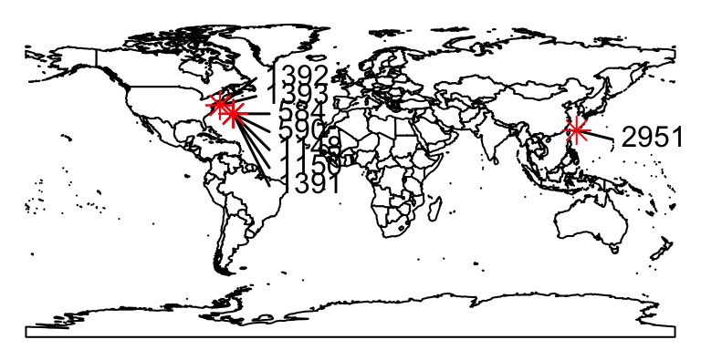

```r
newmap <- getMap(resolution="low")
par(mar=c(0,0,0,0))
plot(newmap,xlim=c(-180,180),ylim=c(-90,90),col='white')
text(metadata$TextLon-5,metadata$TextLat,metadata$Strain,pos=4)
arrows(metadata$Lon,metadata$Lat,metadata$TextLon,metadata$TextLat,length=0,lwd=1.5)
points(metadata$Lon,metadata$Lat,pch=8,cex=1.5,col='red')
```

# Supplemental figure on bacterial abundance

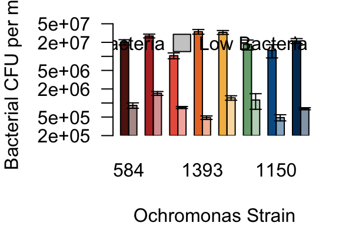

```r
# Some data cleanup
bact.counts$Bact.short <- substr(bact.counts$Rice,1,1) # Uses the first character of the bacterial treatment as the identifier
bact.counts$Strain <- factor(bact.counts$OchStrain,levels=strains) # Orders the strains for plotting according to growth differential

par(mar=c(4,5,1,1))
bargraph.CI(Strain,CFUpmL,group=Bact.short,data=bact.counts[bact.counts$OchStrain!=2616&bact.counts$OldData!='Y',],log='y',ylim=c(2e5,53000000),las=1,xlab='Ochromonas Strain',ylab='', col=mega.col.strains,err.width=.05)
mtext('Bacterial CFU per mL', side = 2, line = 4)
legend(x='topright',inset=-.02,legend=c('High Bacteria','Low Bacteria'),pch=22,pt.cex=2.3,horiz=T,bty='n',pt.bg=c('black','gray80'))
```

# Phylogeny explorations

How to conduct a Mantel test: https://stats.oarc.ucla.edu/r/faq/how-can-i-perform-a-mantel-test-in-r/

```r
# excise 2616 data from matrix of base pair substitutions
gendist <- gendist[gendist$X!=2616,]
gendist <- gendist[,1:9]


# create a matrix of physiology summary data to perform correlational analysis on
strainsumm <- as.data.frame(gendist[,1])
colnames(strainsumm) <- 'Strain'

growth.summ.C$Strain3 <- factor(growth.summ.C$Strain,levels=strainsumm$Strain)

# insert max data
strainsumm$growth.max <- tapply(growth.summ.C$Growth.Rate,growth.summ.C$Strain3,FUN= max,na.rm=T)
strainsumm$chl.max <- tapply(growth.summ.C$mean.chl,growth.summ.C$Strain3,FUN= max,na.rm=T)
strainsumm$att.max <- tapply(growth.summ.C$mean.att,growth.summ.C$Strain3,FUN= max,na.rm=T)
strainsumm$phot.max <- tapply(growth.summ.C$mean.phot,growth.summ.C$Strain3,FUN= max,na.rm=T)
strainsumm$graz.max <- tapply(growth.summ.C$mean.graz,growth.summ.C$Strain3,FUN= max,na.rm=T)

# insert data ranges
strainsumm$growth.range <- tapply(growth.summ.C$Growth.Rate,growth.summ.C$Strain3,FUN= max,na.rm=T)-tapply(growth.summ.C$Growth.Rate,growth.summ.C$Strain3,FUN= min,na.rm=T)
strainsumm$chl.range <- tapply(growth.summ.C$mean.chl,growth.summ.C$Strain3,FUN= max,na.rm=T)-tapply(growth.summ.C$mean.chl,growth.summ.C$Strain3,FUN= min,na.rm=T)
strainsumm$att.range <- tapply(growth.summ.C$mean.att,growth.summ.C$Strain3,FUN= max,na.rm=T)-tapply(growth.summ.C$mean.att,growth.summ.C$Strain3,FUN= min,na.rm=T)
strainsumm$phot.range <- tapply(growth.summ.C$mean.phot,growth.summ.C$Strain3,FUN= max,na.rm=T)-tapply(growth.summ.C$mean.phot,growth.summ.C$Strain3,FUN= min,na.rm=T)
strainsumm$graz.range <- tapply(growth.summ.C$mean.graz,growth.summ.C$Strain3,FUN= max,na.rm=T)-tapply(growth.summ.C$mean.graz,growth.summ.C$Strain3,FUN= min,na.rm=T)

# compute the distance matrix for physiology
physiodist <- dist(prcomp(strainsumm[,2:dim(strainsumm)[2]])$x,diag=T,upper=T)

physiodist <- dist(prcomp(strainsumm[,7:11])$x,diag=T,upper=T)

mantel.test(gendist[,2:9],as.matrix(physiodist))
```

```
## $z.stat
## [1] 18655.04
##
## $p
## [1] 0.273
##
## $alternative
## [1] "two.sided"
```

Results suggest no strong correlation between genetic distance and physiological differences.